# index

## Imports:

```python
import numpy as np
import pandas as pd
import matplotlib.pyplot as plt
```

## Uploading the data:

```python
df = pd.read_csv('Electric_Vehicle_Population_Data.csv')
```

## Preprocessing and Cleaning:

Very little preprocessing and cleaning was needed. Our data does not have any visible human error, duplicates, or useless information. We had some N/A data that was removed. After removing the null data our dataset got smaller.

We can see here that our dataset has 159467 entities and 17 colums

```python
df.shape
```

```
(159467, 17)
```

Here we see that we have no duplicates in the dataset

```python
df.duplicated().sum()
```

```
0
```

We can see here that our dataset has null values in it. While it is a relatively small amount we will benefit from removing them.

```python
df.isnull().sum()
```

```
VIN (1-10)                                             0
County                                                 4
City                                                   4
State                                                  0
Postal Code                                            4
Model Year                                             0
Make                                                   0
Model                                                  0
Electric Vehicle Type                                  0
Clean Alternative Fuel Vehicle (CAFV) Eligibility      0
Electric Range                                         0
Base MSRP                                              0
Legislative District                                 361
DOL Vehicle ID                                         0
Vehicle Location                                       9
Electric Utility                                       4
2020 Census Tract                                      4
dtype: int64
```

After cleaning the data we no longer have any null values.

```python
clean_df = df.dropna()
clean_df.isnull().sum()
```

[output not shown]

We can see that our dataset is slightly smaller than it was before. We only have 159101 entities which is less than the 159467 from before cleaning. At this point we can continue on to EDA and Visualization since our data cleaning is finished.

```python
clean_df.shape
```

```
(159101, 17)
```

## EDA and Visualization:

For our EDA and Visualization we created explored all of our data and found that the dataset is about electric vehicles in the state of Washington. Our data was collected by the Washington State Department of Licensing and shows the electric vehicles registered in the state up to November 17th, 2023. This dataset accounts for the VIN number of each car, the location data, the make and model, and other useful information about the electric cars.

```python
clean_df.info()
```

```
<class 'pandas.core.frame.DataFrame'>
Int64Index: 159101 entries, 0 to 159466
Data columns (total 17 columns):
 #   Column                                             Non-Null Count   Dtype
---  ------                                             --------------   -----
 0   VIN (1-10)                                         159101 non-null  object
 1   County                                             159101 non-null  object
 2   City                                               159101 non-null  object
 3   State                                              159101 non-null  object
 4   Postal Code                                        159101 non-null  float64
 5   Model Year                                         159101 non-null  int64
 6   Make                                               159101 non-null  object
 7   Model                                              159101 non-null  object
 8   Electric Vehicle Type                              159101 non-null  object
 9   Clean Alternative Fuel Vehicle (CAFV) Eligibility  159101 non-null  object
 10  Electric Range                                     159101 non-null  int64
 11  Base MSRP                                          159101 non-null  int64
 12  Legislative District                               159101 non-null  float64
 13  DOL Vehicle ID                                     159101 non-null  int64
 14  Vehicle Location                                   159101 non-null  object
 15  Electric Utility                                   159101 non-null  object
 16  2020 Census Tract                                  159101 non-null  float64
dtypes: float64(3), int64(4), object(10)
memory usage: 21.8+ MB
```

The data here is sorted by city. This is the best way for the data to be sorted since our questions frequently sort by city.

```python
clean_df.sort_values('City')
```

|  | VIN (1-10) | County | City | State | Postal Code | Model Year | Make | Model | Electric Vehicle Type | Clean Alternative Fuel Vehicle (CAFV) Eligibility | Electric Range | Base MSRP | Legislative District | DOL Vehicle ID | Vehicle Location | Electric Utility | 2020 Census Tract |
| --- | --- | --- | --- | --- | --- | --- | --- | --- | --- | --- | --- | --- | --- | --- | --- | --- | --- |
| 73090 | 5YJ3E1EA1J | Grays Harbor | Aberdeen | WA | 98520.0 | 2018 | TESLA | MODEL 3 | Battery Electric Vehicle (BEV) | Clean Alternative Fuel Vehicle Eligible | 215 | 0 | 19.0 | 333233806 | POINT (-123.8206 46.97789) | BONNEVILLE POWER ADMINISTRATION\|\|PUD NO 1 OF G... | 5.302700e+10 |
| 135627 | KNDPZDAH9P | Grays Harbor | Aberdeen | WA | 98520.0 | 2023 | KIA | SPORTAGE | Plug-in Hybrid Electric Vehicle (PHEV) | Clean Alternative Fuel Vehicle Eligible | 34 | 0 | 19.0 | 255193585 | POINT (-123.8206 46.97789) | BONNEVILLE POWER ADMINISTRATION\|\|PUD NO 1 OF G... | 5.302700e+10 |
| 66153 | 3FMTK2R70N | Grays Harbor | Aberdeen | WA | 98520.0 | 2022 | FORD | MUSTANG MACH-E | Battery Electric Vehicle (BEV) | Eligibility unknown as battery range has not b... | 0 | 0 | 19.0 | 202272654 | POINT (-123.8206 46.97789) | BONNEVILLE POWER ADMINISTRATION\|\|PUD NO 1 OF G... | 5.302700e+10 |
| 142815 | 5YJ3E1EB7N | Grays Harbor | Aberdeen | WA | 98520.0 | 2022 | TESLA | MODEL 3 | Battery Electric Vehicle (BEV) | Eligibility unknown as battery range has not b... | 0 | 0 | 19.0 | 187406131 | POINT (-123.8206 46.97789) | BONNEVILLE POWER ADMINISTRATION\|\|PUD NO 1 OF G... | 5.302700e+10 |
| 59054 | 1N4AZ0CP1D | Grays Harbor | Aberdeen | WA | 98520.0 | 2013 | NISSAN | LEAF | Battery Electric Vehicle (BEV) | Clean Alternative Fuel Vehicle Eligible | 75 | 0 | 19.0 | 193004612 | POINT (-123.8206 46.97789) | BONNEVILLE POWER ADMINISTRATION\|\|PUD NO 1 OF G... | 5.302700e+10 |
| ... | ... | ... | ... | ... | ... | ... | ... | ... | ... | ... | ... | ... | ... | ... | ... | ... | ... |
| 120972 | 1V2DNPE80P | Yakima | Zillah | WA | 98953.0 | 2023 | VOLKSWAGEN | ID.4 | Battery Electric Vehicle (BEV) | Eligibility unknown as battery range has not b... | 0 | 0 | 15.0 | 256438024 | POINT (-120.26317 46.40556) | PACIFICORP | 5.307700e+10 |
| 56549 | YV4ED3GB1N | Yakima | Zillah | WA | 98953.0 | 2022 | VOLVO | C40 | Battery Electric Vehicle (BEV) | Eligibility unknown as battery range has not b... | 0 | 0 | 15.0 | 207472457 | POINT (-120.26317 46.40556) | PACIFICORP | 5.307700e+10 |
| 104247 | JN1AZ0CP0C | Yakima | Zillah | WA | 98953.0 | 2012 | NISSAN | LEAF | Battery Electric Vehicle (BEV) | Clean Alternative Fuel Vehicle Eligible | 73 | 0 | 15.0 | 185917665 | POINT (-120.26317 46.40556) | PACIFICORP | 5.307700e+10 |
| 71350 | JN1AZ0CP8B | Yakima | Zillah | WA | 98953.0 | 2011 | NISSAN | LEAF | Battery Electric Vehicle (BEV) | Clean Alternative Fuel Vehicle Eligible | 73 | 0 | 15.0 | 103929164 | POINT (-120.26317 46.40556) | PACIFICORP | 5.307700e+10 |
| 40717 | SADHD2S16K | Yakima | Zillah | WA | 98953.0 | 2019 | JAGUAR | I-PACE | Battery Electric Vehicle (BEV) | Clean Alternative Fuel Vehicle Eligible | 234 | 0 | 15.0 | 477559785 | POINT (-120.26317 46.40556) | PACIFICORP | 5.307700e+10 |

159101 rows × 17 columns

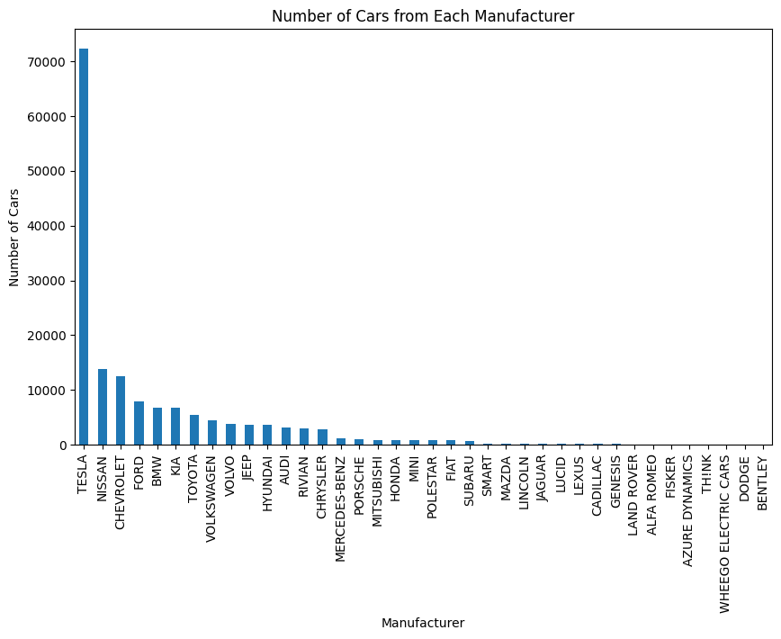

```python
#cars_2015 = clean_df[clean_df['Model Year'] == 2015]

manufacturer_counts = clean_df['Make'].value_counts()

plt.figure(figsize=(10, 6))
manufacturer_counts.plot(kind='bar')
plt.title('Number of Cars from Each Manufacturer')
plt.xlabel('Manufacturer')
plt.ylabel('Number of Cars')
plt.show()
```

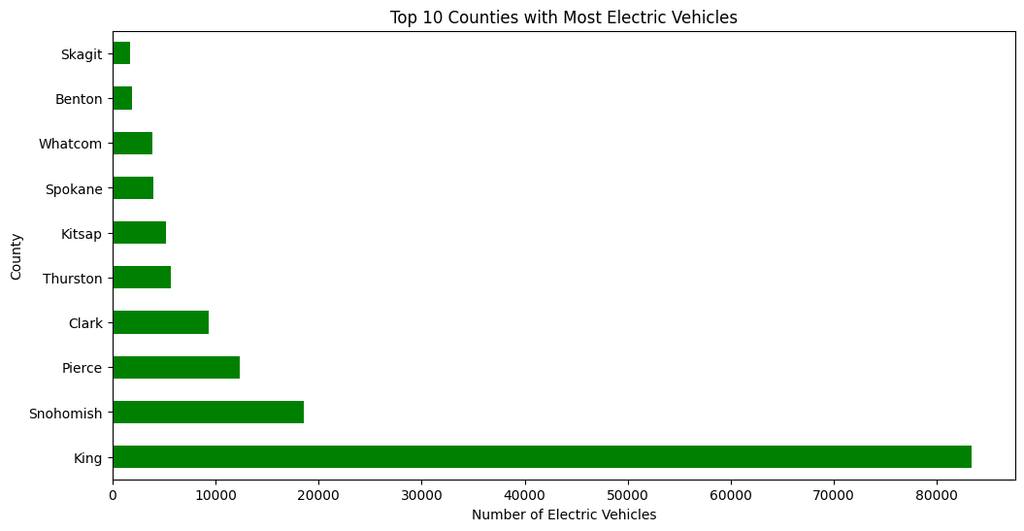

```python
country_counts = clean_df['County'].value_counts().head(10)
plt.figure(figsize=(12, 6))
country_counts.plot(kind='barh', color='green')
plt.title('Top 10 Counties with Most Electric Vehicles')
plt.xlabel('Number of Electric Vehicles')
plt.ylabel('County')
plt.show()
```

## Research Questions:

In this section he have our research questions and analysis. We have 8 total question and they are listen below.

### Question 1:

What model car is the most popular from Seattle?  
To answer this question we select the city Seattle and count each of the models. We then found the most popular model using the idxmax() function. After doing this we were able to create a bar plot that shows us the 10 most popular car models. We see that the most popular is the Tesla model 3 with nearly 5,000 cars in Seattle. This bar plot shows us that 4 of the 10 most popular car models in Seattle are Telsa cars, specifically the Model 3, Model Y, Model S, and Model X. This should be expected since Telsa was the most popular electric vehicle brand in the state of Washington.

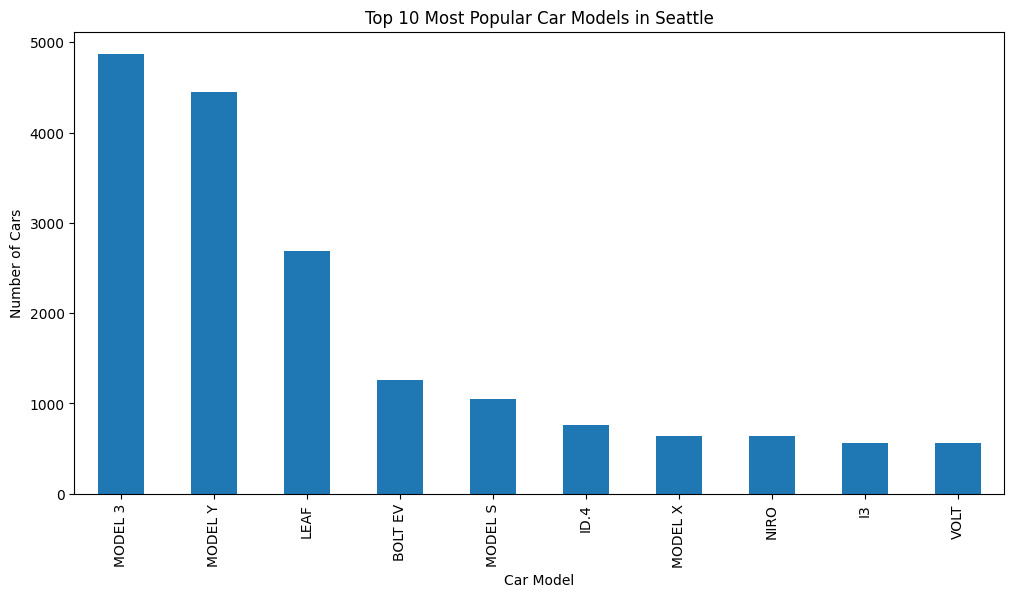

```python
most_popular_model_seattle = clean_df[clean_df['City'] == 'Seattle']['Model'].value_counts().idxmax()


model_counts = clean_df[clean_df['City'] == 'Seattle']['Model'].value_counts().head(10)
plt.figure(figsize=(12, 6))
model_counts.plot(kind='bar')
plt.title('Top 10 Most Popular Car Models in Seattle')
plt.xlabel('Car Model')
plt.ylabel('Number of Cars')
plt.show()
```

### Question 2:

What city has the most electric cars?

To answer this question we select the Plug-in Hybrid Electric Vehicle (PHEV) from Electric Vehicle Type and select city and use idxmax() to find the city with the most electric cars. After this, we created a bar graph showing the 10 cities with the most electric cars. Here it can be seen that Seattle has the most electric cars by over 3000, which makes sense since it is the biggest city out of the 10. The bar graph also shows us that the difference in electric vehicles from Seattle to Vancouver is much greater than the difference between Vancouver and Botnell.

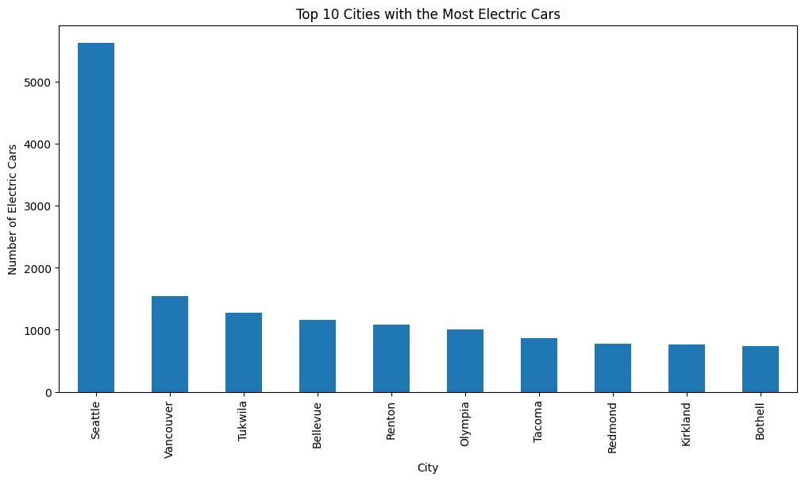

```python
city_most_electric_cars = clean_df[clean_df['Electric Vehicle Type'] == 'Plug-in Hybrid Electric Vehicle (PHEV)']['City'].value_counts().idxmax()


city_counts = clean_df[clean_df['Electric Vehicle Type'] == 'Plug-in Hybrid Electric Vehicle (PHEV)']['City'].value_counts().head(10)
plt.figure(figsize=(12, 6))
city_counts.plot(kind='bar')
plt.title('Top 10 Cities with the Most Electric Cars')
plt.xlabel('City')
plt.ylabel('Number of Electric Cars')
plt.show()
```

### Question 3:

What vehicle type is most common?  
Here we are selecting the electric vehicle type in the clean_df. After selecting the electric vehicle type we count the values of each type. After counting the different types we use the idxmax() function to find which electric vehicle type is the most common. The code tells us that 'Battery Electric Vehicle (BEV)' are the most common electric vehicle types in the state of Washington. We then create a pie chart of the electric vehicle types. From reading this chart we see that 77.9% of the electric vehicle types are Battery Electric Vehicles (BEV) whilte 22.1% of the electric vehicle types are 'Plug-in Hybrid Electric Vehicle (PHEV)'.

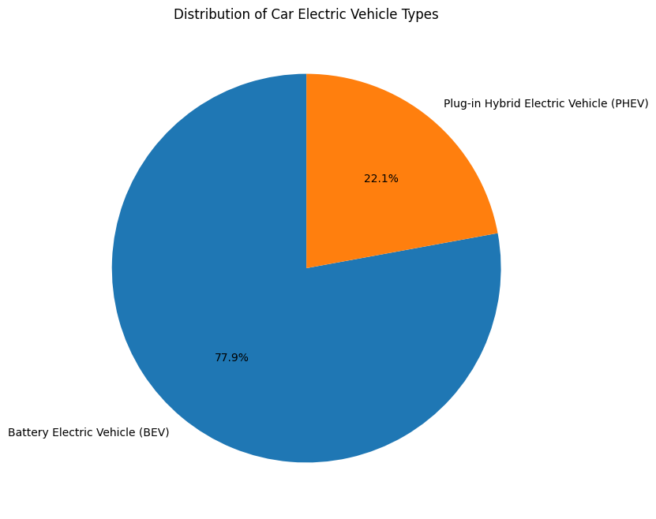

```python
most_common_vehicle_type = clean_df['Electric Vehicle Type'].value_counts().idxmax()
most_common_vehicle_type

fuel_type_counts = clean_df['Electric Vehicle Type'].value_counts()
plt.figure(figsize=(8, 8))
plt.pie(fuel_type_counts, labels=fuel_type_counts.index, autopct='%1.1f%%', startangle=90)
plt.title('Distribution of Car Electric Vehicle Types')
plt.show()
```

### Question 4:

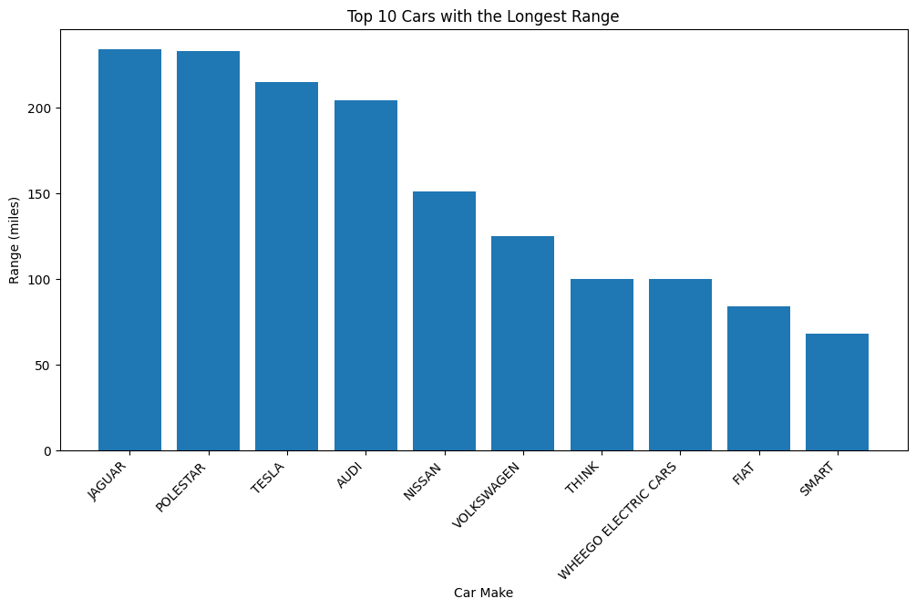

```python
longest_range_cars = clean_df.loc[clean_df['Electric Range'].idxmax()]

top_cars = clean_df.drop_duplicates(subset=['Make']).nlargest(10, 'Electric Range')

plt.figure(figsize=(12, 6))
plt.bar(top_cars['Make'], top_cars['Electric Range'])
plt.title('Top 10 Cars with the Longest Range')
plt.xlabel('Car Make')
plt.ylabel('Range (miles)')
plt.xticks(rotation=45, ha='right')
plt.show()
```

### Question 5:

What manufacturer makes the most electric vehicles?

To answer this question, we select the Plug-in Hybrid Electric Vehicle type from clean_df, then we use the idmax function to show how many electric vehicles each brand manufactures so that we can tell which one has the most. Then, we use the plt functions to create a bar graph showing the 10 manufacturers that make the most cars. This tells us that we have the most Toyotas with 5,268 Plug-in Hybrid Electric Vehicles (PHEV)

```
<bound method Series.idxmax of TOYOTA                  5268
CHEVROLET               4862
BMW                     4802
JEEP                    3679
FORD                    3654
CHRYSLER                2844
VOLVO                   2469
KIA                     2220
AUDI                    1358
MITSUBISHI               848
HONDA                    831
HYUNDAI                  535
PORSCHE                  482
MAZDA                    269
MERCEDES-BENZ            260
LINCOLN                  235
MINI                     220
LEXUS                    113
CADILLAC                  87
SUBARU                    64
LAND ROVER                47
ALFA ROMEO                19
FISKER                    15
WHEEGO ELECTRIC CARS       3
DODGE                      2
BENTLEY                    2
Name: Make, dtype: int64>
```

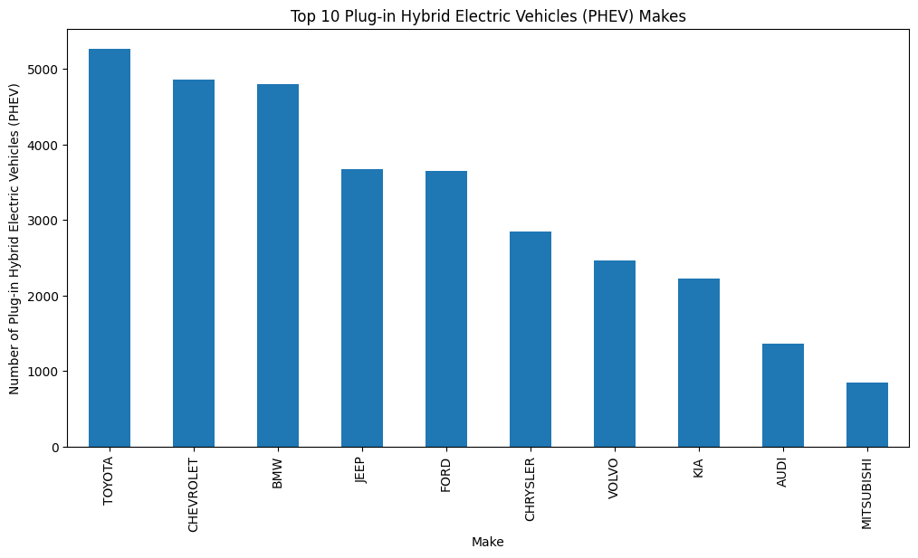

```python
make_most_electric_models = clean_df[clean_df['Electric Vehicle Type'] == 'Plug-in Hybrid Electric Vehicle (PHEV)']['Make'].value_counts().idxmax
print(make_most_electric_models)

make_most_electric_models_count = clean_df[clean_df['Electric Vehicle Type'] == 'Plug-in Hybrid Electric Vehicle (PHEV)']['Make'].value_counts().head(10)
plt.figure(figsize=(12, 6))
make_most_electric_models_count.plot(kind='bar')
plt.title('Top 10 Plug-in Hybrid Electric Vehicles (PHEV) Makes')
plt.xlabel('Make')
plt.ylabel('Number of Plug-in Hybrid Electric Vehicles (PHEV)')
plt.show()
```

### Question 6:

Are there more hybrid or fully electric vehicles?

There are many more Battery Electric Vehicles or full electric vehicles. To answer this question we decided to make a pie chart that visualizes the general distribution of Electric vehicles by their fuel type based on our dataset. Our chart displays a clear disparity in the number of electric vehicle sales depending on whether it’s a full electric vehicle or a plug-in hybrid. The chart indicates that consumers tend to purchase battery electric vehicles which are full electric vehicles 77.9 percent of the time according to the distribution. While only 22.1 percent of electric vehicles on the road are plug in hybrids.

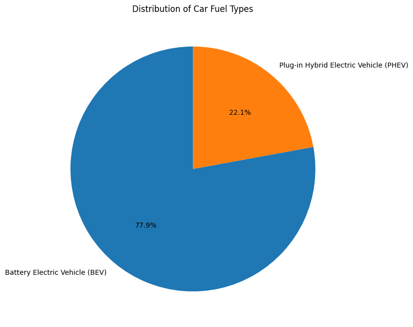

```python
hybrid_vs_electric_count = clean_df['Electric Vehicle Type'].value_counts()


fuel_type_counts = clean_df['Electric Vehicle Type'].value_counts()
plt.figure(figsize=(8, 8))
plt.pie(fuel_type_counts, labels=fuel_type_counts.index, autopct='%1.1f%%', startangle=90)
plt.title('Distribution of Car Fuel Types')
plt.show()
```

### Question 7:

What was the most expensive brand of cars?

The most expensive car brand is Fisker. We solved this question by grouping the data by make and Base MSRP/Price. After doing this we found the mean of the price and determined the max using idxmax. Then we were able to produce a bar plot of our data. We found that Fisker was the most expensive brand with an average price of 95625 while WHEEGO ELECTRIC CARS is the next most expensive brand with an average price of 32995.

```
<bound method Series.idxmax of Make
ALFA ROMEO                  0.000000
AUDI                        0.000000
AZURE DYNAMICS              0.000000
BENTLEY                     0.000000
BMW                      3889.462507
CADILLAC                 4597.653061
CHEVROLET                   0.000000
CHRYSLER                 1631.300985
DODGE                       0.000000
FIAT                        0.000000
FISKER                  95625.000000
FORD                        0.000000
GENESIS                     0.000000
HONDA                       0.000000
HYUNDAI                     0.000000
JAGUAR                      0.000000
JEEP                        0.000000
KIA                      2914.307966
LAND ROVER                  0.000000
LEXUS                       0.000000
LINCOLN                     0.000000
LUCID                       0.000000
MAZDA                       0.000000
MERCEDES-BENZ               0.000000
MINI                     7049.573691
MITSUBISHI                  0.000000
NISSAN                      0.000000
POLESTAR                    0.000000
PORSCHE                  4051.691729
RIVIAN                      0.000000
SMART                       0.000000
SUBARU                   3250.624093
TESLA                    1552.946426
TH!NK                       0.000000
TOYOTA                      0.000000
VOLKSWAGEN                  0.000000
VOLVO                    4531.736687
WHEEGO ELECTRIC CARS    32995.000000
Name: Base MSRP, dtype: float64>
```

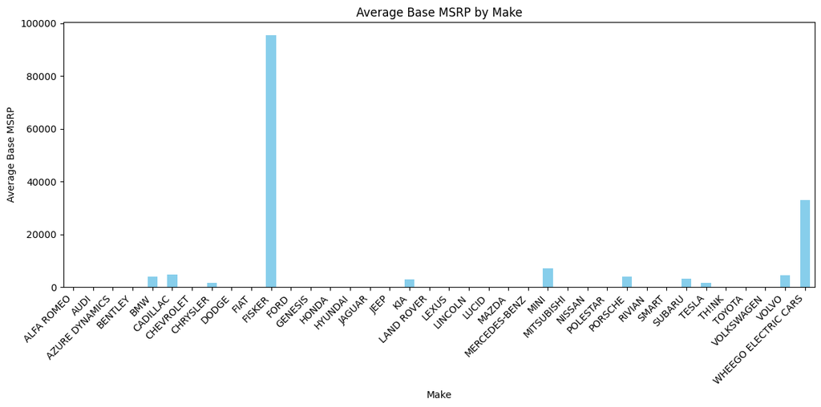

```python
most_expensive_brand = clean_df.groupby('Make')['Base MSRP'].mean().idxmax
print(most_expensive_brand)

average_prices = clean_df.groupby('Make')['Base MSRP'].mean()
plt.figure(figsize=(12, 6))
average_prices.plot(kind='bar', color='skyblue')
plt.title('Average Base MSRP by Make')
plt.xlabel('Make')
plt.ylabel('Average Base MSRP')
plt.xticks(rotation=45, ha='right')
plt.tight_layout()
plt.show()
```

### Question 8:

How Many electric vehicles were sold by each of the top manufacturers in 2015?

To answer this question, we decided to make a graph the visualizes the distribution of electric vehicles sold by the top manufacturers in 2015 by manufacturer. This shows which manufacturers were early to the market when electric vehicles were relatively new to the auto industry. The graph clearly shows that companies like Nissan with 1750 sales, Tesla with 1100 sales, and Ford with 500 sales had the most sales during 2015 and were the top 3 manufacturers during that year. The graph also clearly visualizes the disparity is sales. Brands like Volkswagen, Toyota, and Smart all sold many fewer vehicles in comparison

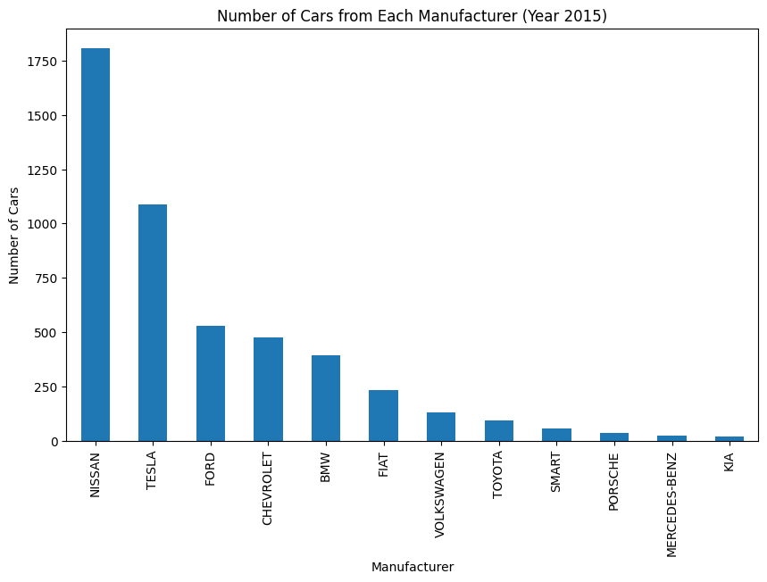

```python
cars_2015 = clean_df[clean_df['Model Year'] == 2015]


manufacturer_counts = cars_2015['Make'].value_counts()

plt.figure(figsize=(10, 6))
manufacturer_counts.plot(kind='bar')
plt.title('Number of Cars from Each Manufacturer (Year 2015)')
plt.xlabel('Manufacturer')
plt.ylabel('Number of Cars')
plt.show()
```

## Conclusion:

Group Members: Lucas Heller & Alfred Liljas

I worked on the code for the questions and data exploration and visualization with a some the help of Lucas and Alfred, We all came up with the questions together as well as worked within a collaborative enviroment. Lucas and Alfred did most of the data cleaning, And we all split up the markdown portion of the assignment. We also met in the HUB and worked on the assignment multiple times.

Thanks for your time and an amazing Semester :) It has been a pleasure being in your DS 220 class.